# Part II - FordGo Bike sharing dataset exploration

## by Muzimba Dingani

## investigation overview

The objective of this presentation is to show and ephasize the key insights in the FordGo bike sharing system:

## Dataset overview

This data set includes information about individual rides made in a bike-sharing system covering the greater San Francisco Bay area.

### 1. How many people who participated in the rides who where willing to share bike for the whole trip?

### visualization 1

- we can note that a lot of people weren't willing to share the bikes for the whole trip

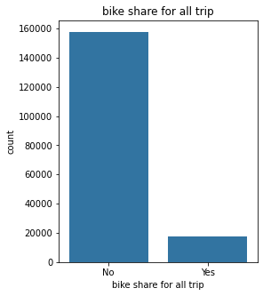

### visualization 2.

- most people who participated were of year 1988.

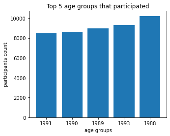

### visualization 3.

- we can note that most of the user who participated where subscribers than customers

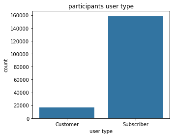

### visualization 4

- participants at the age of 26-41(milliennials) participated the most and most of them were male.
- We can also noticed that most of the Gen X participants were male

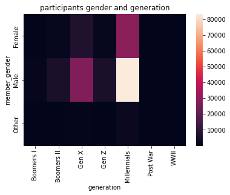

### visualization 5.

- most participants who had the highest mean duration of seconds were of the age between 68-76 and they were most customers to subscribes
- most participants who had the highest mean duration of seconds and who were subscribes were of the age between 58-75.

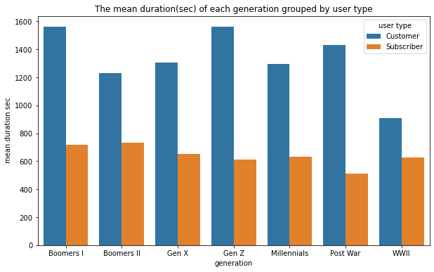